# Correlation

Ariana Fairbanks

11/27/2018

1.0

### Functions introduced in this module:

`cor`, `cor.test`

## Introduction

In this module we will learn how to run a correlation analysis. Correlation measures the strength of the linear relationship between two numerical variables.

## Load packages

We load the standard `mosaic` package as well as the `reshape2` package for the `tips` data and the `OIdata` package for the `state` data. The `broom` package gives us tidy output.

```r
library(reshape2)
library(OIdata)
data(state)
library(broom)
library(mosaic)
```

We set the seed to make our results reproducible.

```r
set.seed(11)
```

## Research question

Is there is a correlation between the size of a restaurant bill and the size of the tip?

## Correlation

The word correlation describes a linear relationship between two numerical variables. As long as certain conditions are met, we can calculate a statistic called the Pearson correlation coefficient, denoted R.[^1] This value will be some number between -1 and 1. Coefficients close to zero indicate little or no correlation, coefficients close to 1 indicate strong positive correlation, and coefficients close to -1 indicate strong negative correlation. In between, we often use words like weak, moderately weak, moderate, and moderately strong. There are no exact cutoffs for when such words apply. You must learn from experience how to judge scatterplots and R values to make such determinations.

Let’s examine a data set called `tips` from the `reshape2` package. Since there is also a `tips` data set in the `openintro` package, we’ll use a trick to make sure we get the right one. The double colon is placed between the name of the package and the name of the data frame:

```r
tips <- reshape2::tips
str(tips)
```

```
'data.frame':   244 obs. of  7 variables:
 $ total_bill: num  17 10.3 21 23.7 24.6 ...
 $ tip       : num  1.01 1.66 3.5 3.31 3.61 4.71 2 3.12 1.96 3.23 ...
 $ sex       : Factor w/ 2 levels "Female","Male": 1 2 2 2 1 2 2 2 2 2 ...
 $ smoker    : Factor w/ 2 levels "No","Yes": 1 1 1 1 1 1 1 1 1 1 ...
 $ day       : Factor w/ 4 levels "Fri","Sat","Sun",..: 3 3 3 3 3 3 3 3 3 3 ...
 $ time      : Factor w/ 2 levels "Dinner","Lunch": 1 1 1 1 1 1 1 1 1 1 ...
 $ size      : int  2 3 3 2 4 4 2 4 2 2 ...
```

These 244 observations were collected by one waiter over a period of a few months working in a restaurant. Our research question asks us to consider the variables `tip` and `total_bill`.

If all we wanted was the value of R, we could find it by using the `cor` command.

```r
R <- cor(tip ~ total_bill, data = tips)
R
```

```
[1] 0.6757341
```

Although the `cor` command accepts the “tilde” notation, the order doesn’t matter; correlation is symmetric, so the R value is the same independent of the choice of response and explanatory variables.

This sample correlation R is an estimate of the true population correlation, called $\rho$, the Greek letter “rho”. A typical null hypothesis is that there is no correlation between the two variables—in other words, $\rho = 0$. Under that assumption, the sampling distribution is somewhat complicated. Although the sample correlations don’t follow a simple distribution, if we calculate

$$t = \frac{R - \rho}{\sqrt{\frac{1 - R^{2}}{n - 2}}} = \frac{R}{\sqrt{\frac{1 - R^{2}}{n - 2}}},$$

then the values of $t$ follow a Student t distribution with $n - 2$ degrees of freedom. (The last step above takes into account the fact that the null value for $\rho$ is zero.)

We can verify this with a basic simulation. First, we shuffle the values of `total_bill` to remove any association with tips to simulate the assumption of the null hypothesis. Here are a few examples:

```r
cor(tip ~ shuffle(total_bill), data = tips)
```

```
[1] 0.005853122
```

```r
cor(tip ~ shuffle(total_bill), data = tips)
```

```
[1] 0.007911685
```

```r
cor(tip ~ shuffle(total_bill), data = tips)
```

```
[1] 0.1027245
```

We use the `do` command to do this a bunch of times.

```r
sims <- do(2000) * cor(tip ~ shuffle(total_bill), data = tips)
sims
```

| cor |
| --- |
| -0.06347553443 |
| 0.07129190174 |
| 0.04798464623 |
| -0.02780594601 |
| -0.03179003628 |
| 0.12528849920 |
| 0.10447459089 |
| -0.00000464522 |
| 0.06510214917 |
| 0.08189434867 |

[output cut: 990 more lines]

The t scores follow a Student t distribution, not the correlations themselves, so we have to calculate the t scores. We use the `mutate` command to compute the t score for each row of `sims`. The number 242 is $n - 2$.

```r
sims <- sims %>%
    mutate(t = cor/(sqrt((1 - cor^2)/242)))
sims
```

| cor | t |
| --- | --- |
| -0.06347553443 | -0.98944289400 |
| 0.07129190174 | 1.11187087849 |
| 0.04798464623 | 0.74732677788 |
| -0.02780594601 | -0.43272632358 |
| -0.03179003628 | -0.49478698573 |
| 0.12528849920 | 1.96451130095 |
| 0.10447459089 | 1.63418620935 |
| -0.00000464522 | -0.00007226267 |
| 0.06510214917 | 1.01490477928 |
| 0.08189434867 | 1.27827077474 |

[output cut: 990 more lines]

Now we can graph the simulated values. We superimpose the t distribution with $df = 242$ to show that it’s a pretty good fit.

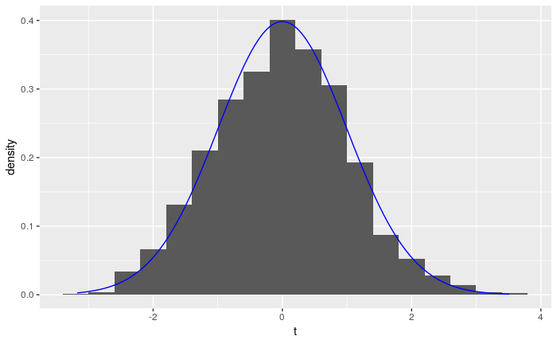

```r
# Don't worry about the syntax here.
# You won't need to know how to do this on your own.
ggplot(sims, aes(x = t)) +
    geom_histogram(aes(y = ..density..), binwidth = 0.4) +
    stat_function(fun = "dt", args = list(df = 242), color = "blue")
```

## Inference for correlation

Calculating a correlation coefficient blindly can be dangerous. Without meeting certain conditions, the value of R could be incredibly misleading. R (the software) will gladly compute R (the correlation coefficient) for any data, whether appropriate or not. Therefore, we will follow our inferential rubric to decide if there is a statistically significant relationship between the tip and the corresponding bill. In truth, the entire inferential rubric is probably overkill for such a simple question. Nevertheless, the rubric does ensure that we take care to identify our sample and population, establish hypotheses, check conditions, and state proper conclusions.

In addition to the standard “Random” and “10%” conditions, we introduce two new conditions. First, we need to know that the association is linear. Nonlinear relationships can exist, but the R value makes no sense for such situations. Finally, we need to check for outliers. These two conditions should be checked by looking at a scatterplot.

## Exploratory data analysis

### Use data documentation (help files, code books, Google, etc.), the `str` command, and other summary functions to understand the data.

[You should type `?tips` at the Console to read the help file.]

```r
tips
```

|  | total_bill | tip | sex | smoker | day | time | size |
| --- | --- | --- | --- | --- | --- | --- | --- |
| 1 | 16.99 | 1.01 | Female | No | Sun | Dinner | 2 |
| 2 | 10.34 | 1.66 | Male | No | Sun | Dinner | 3 |
| 3 | 21.01 | 3.50 | Male | No | Sun | Dinner | 3 |
| 4 | 23.68 | 3.31 | Male | No | Sun | Dinner | 2 |
| 5 | 24.59 | 3.61 | Female | No | Sun | Dinner | 4 |
| 6 | 25.29 | 4.71 | Male | No | Sun | Dinner | 4 |
| 7 | 8.77 | 2.00 | Male | No | Sun | Dinner | 2 |
| 8 | 26.88 | 3.12 | Male | No | Sun | Dinner | 4 |
| 9 | 15.04 | 1.96 | Male | No | Sun | Dinner | 2 |
| 10 | 14.78 | 3.23 | Male | No | Sun | Dinner | 2 |

[output cut: 234 more lines]

```r
str(tips)
```

```
'data.frame':   244 obs. of  7 variables:
 $ total_bill: num  17 10.3 21 23.7 24.6 ...
 $ tip       : num  1.01 1.66 3.5 3.31 3.61 4.71 2 3.12 1.96 3.23 ...
 $ sex       : Factor w/ 2 levels "Female","Male": 1 2 2 2 1 2 2 2 2 2 ...
 $ smoker    : Factor w/ 2 levels "No","Yes": 1 1 1 1 1 1 1 1 1 1 ...
 $ day       : Factor w/ 4 levels "Fri","Sat","Sun",..: 3 3 3 3 3 3 3 3 3 3 ...
 $ time      : Factor w/ 2 levels "Dinner","Lunch": 1 1 1 1 1 1 1 1 1 1 ...
 $ size      : int  2 3 3 2 4 4 2 4 2 2 ...
```

We can also look at each numerical variable individually with `favstats`:

```r
favstats(tips$tip)
```

|  | min | Q1 | median | Q3 | max | mean | sd | n | missing |
| --- | --- | --- | --- | --- | --- | --- | --- | --- | --- |
|  | 1 | 2 | 2.9 | 3.5625 | 10 | 2.998279 | 1.383638 | 244 | 0 |

```r
favstats(tips$total_bill)
```

|  | min | Q1 | median | Q3 | max | mean | sd | n | missing |
| --- | --- | --- | --- | --- | --- | --- | --- | --- | --- |
|  | 3.07 | 13.3475 | 17.795 | 24.1275 | 50.81 | 19.78594 | 8.902412 | 244 | 0 |

### Prepare the data for analysis. [Not always necessary.]

The two variables of interest are coded correctly as numerical variables in the `tips` data frame, so we don’t need to do anything for this step.

### Make tables or plots to explore the data visually.

The appropriate plot for two numerical variables is a scatterplot. We are thinking of `tip` as the response variable and `total_bill` as the explanatory variable.

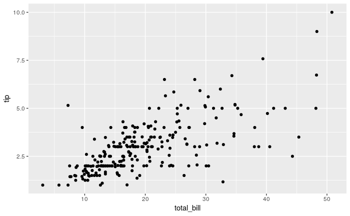

```r
ggplot(tips, aes(y = tip, x = total_bill)) +
    geom_point()
```

There does appear to be a moderate, positive association between these variables.

##### Exercise 1

There appears to be a pattern of unusual bunching into horizontal lines in the lower left part of the graph. Can you explain this pattern? (Hint: use `arrange` to sort the `tip` variable. We’ve used the `arrange` command several times in the modules before, but if you need a reminder, you can go back to the module “5. Manipulating data”.)

```r
arrange(tips, tip)
```

| total_bill | tip | sex | smoker | day | time | size |
| --- | --- | --- | --- | --- | --- | --- |
| 3.07 | 1.00 | Female | Yes | Sat | Dinner | 1 |
| 5.75 | 1.00 | Female | Yes | Fri | Dinner | 2 |
| 7.25 | 1.00 | Female | No | Sat | Dinner | 1 |
| 12.60 | 1.00 | Male | Yes | Sat | Dinner | 2 |
| 16.99 | 1.01 | Female | No | Sun | Dinner | 2 |
| 12.90 | 1.10 | Female | Yes | Sat | Dinner | 2 |
| 32.83 | 1.17 | Male | Yes | Sat | Dinner | 2 |
| 10.51 | 1.25 | Male | No | Sat | Dinner | 2 |
| 8.51 | 1.25 | Female | No | Thur | Lunch | 2 |
| 10.07 | 1.25 | Male | No | Sat | Dinner | 2 |

[output cut: 234 more lines]

There are multiple instances of people giving tips of roughly the same ammount despite differences of several dollars in the size of their total bill.

## Hypotheses

### Identify the sample (or samples) and a reasonable population (or populations) of interest.

The sample consists of 244 meals a waiter served over the course of several months working at a restaurant. The population is presumably all meals this waiter might ever serve at this restaurant. (It would not make sense to include other servers or other restaurants in this population as bills and tips vary widely from person to person and restaurant to restaurant.)

### Express the null and alternative hypotheses as contextually meaningful full sentences.

$H_{0}:$ There is no correlation between the tip and the total bill.

$H_{A}:$ There is a correlation between the tip and the total bill.

### Express the null and alternative hypotheses in symbols (when possible).

$H_{0}: \rho = 0$

$H_{A}: \rho \neq 0$.

Commentary: We are performing a two-sided test here. One could perform a one-sided test if the question of interest was about a positive or a negative correlation specifically. Unless otherwise specified, though, the default is to run a two-sided test.

## Model

### Identify the sampling distribution model.

We use a t model with 242 degrees of freedom.

### Check the relevant conditions to ensure that model assumptions are met.

- Random
  - This is not a random sample, but over several months, it seems reasonable that this is representative of this waiter’s experiences at this restaurant.
- 10%
  - Assuming the waiter works at this restaurant for several years, 244 meals is probably less than 10% of all meals he will serve.
- Linear association
  - The scatterplot shows a reasonably linear pattern.
- Outliers
  - We don’t see any significant outliers in the scatterplot. There are a few dots here and there that are a little far from the main cloud, but nothing that worries us too much, especially given the large sample size.

Commentary: No data will ever line up in a perfect straight line. The “linear association” condition is meant to suggest that the “cloud of dots” should be more or less in a straight pattern moving across the plot. We are most concerned here with checking that the pattern does not curve substantially, and this does not appear to. As with any outliers, judge them based on how far away from the data cloud they are, and keep in mind that outliers tend to be more influential when sample sizes are small.

## Mechanics

### Compute and report the test statistic.

```r
tips_test <- cor.test(tip ~ total_bill, data = tips)
tips_test_tidy <- tidy(tips_test)
tips_test_tidy
```

| estimate | statistic | p.value | parameter | conf.low | conf.high | method | alternative |
| --- | --- | --- | --- | --- | --- | --- | --- |
| 0.6757341 | 14.26035 | 0.0000000000000000000000000000000006692471 | 242 | 0.6011647 | 0.7386372 | Pearson's product-moment correlation | two.sided |

```r
t1 <- tips_test_tidy$statistic
t1
```

```
[1] 14.26035
```

The t score is 14.260355.

Commentary: Although `cor.test` accepts the “tilde” notation, the order doesn’t matter; correlation is symmetric, so the R value is the same independent of the choice of response and explanatory variables.

The output of the `cor.test` function is very similar to other hypothesis tests in R. The correlation coefficient is the `estimate`. Everything else is straightforward: the t score (`statistic`), P-value (`p.value`), degrees of freedom (`parameter`), and confidence interval (`conf.low` and `conf.high`).

You may have noticed that this is an insanely large t score. This is typical of correlation tests. If there is enough visual evidence of a correlation in the scatterplot, the R value will be pretty far from 0. That’s why the full rubric for inference is somewhat overkill for questions about correlation.

### Plot the null distribution.

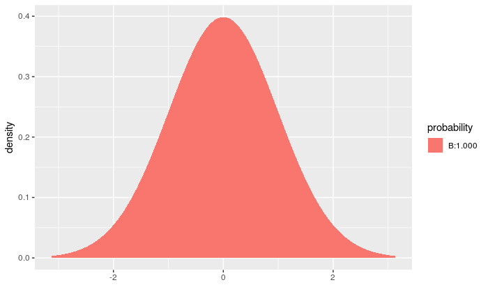

```r
pdist("t", df = tips_test_tidy$parameter,
      q = c(-t1, t1),
      invisible = TRUE)
```

### Calculate and report the P-value.

```r
P1 <- tips_test_tidy$p.value
P1
```

```
[1] 6.692471e-34
```

$P < 0.001$. If there were truly no correlation between tips and the total bill, there would be less than a 0.1% chance of seeing results at least as extreme as we saw in the data.

Commentary: $P < 0.001$ is quite the understatement. The P-value has 33 zeros after the decimal point! In fact, notice in the interpretation of the P-value, we don’t even use inline R code because R would try to round it down to zero. Observe: 0%. See? And we never want to say that the P-value is zero because it literally cannot be zero, even though it’s very close.

## Conclusion

### State the statistical conclusion.

We reject the null hypothesis.

### State (but do not overstate) a contextually meaningful conclusion.

There is sufficient evidence that there is a correlation between the tip and the total bill (for this waiter at this restaurant).

### Identify the possibility of either a Type I or Type II error and state what making such an error means in the context of the hypotheses.

If we’ve made a Type I error, then there is actually no correlation between tips and the total bill, but this data shows one.

## Confidence interval

### Check the relevant conditions to ensure that model assumptions are met.

All the conditions have already been checked.

### Calculate the confidence interval.

```r
tips_test_tidy$conf.low
```

```
[1] 0.6011647
```

```r
tips_test_tidy$conf.high
```

```
[1] 0.7386372
```

### State (but do not overstate) a contextually meaningful interpretation.

We are 95% confident that the true correlation between tips and the total bill (for this waiter at this restaurant) is captured in the interval (0.6011647, 0.7386372).

### If running a two-sided test, explain how the confidence interval reinforces the conclusion of the hypothesis test.

Since zero is not contained in the confidence interval, zero is not a plausible value for the correlation between tips and the total bill.

## Your turn

The `state` data from the `OIdata` package has a number of variables collected from various sources. There are 51 rows, representing the 50 states and the District of Columbia. Run a correlation test to determine if the percentage of the state’s population that smokes is correlated with the median household income in each state.

There is something unusual about this example that you will need to consider in your answer. The sample is 50 states and the District of Columbia. The population is tricky though because these states don’t represent some larger groups of states; we already have all the states in our data. One can think of this data, though, as a snapshot of what was true in each state at one point in time. Therefore, the population can be thought of as similar measurements taken at other times.

This also makes it difficult to check conditions. We do not have a random sample of states (as we have all of them), but remember that we’re thinking of this as a sample across a number of years in which we might have gathered this data. Having said that, I imagine that median income goes up every year with inflation, so it may or may not be representative of other years. The 10% condition also requires some thought.

##### Exploratory data analysis

###### Use data documentation (help files, code books, Google, etc.), the `str` command, and other summary functions to understand the data.

```r
str(state)
```

```
'data.frame':   51 obs. of  24 variables:
 $ state           : Factor w/ 52 levels "Alabama","Alaska",..: 1 2 3 4 5 6 7 8 9 10 ...
 $ abbr            : Factor w/ 52 levels "AK","AL","AR",..: 2 1 4 3 5 6 7 9 8 10 ...
 $ fips            : num  1 2 4 5 6 8 9 10 11 12 ...
 $ pop2010         : num  4779736 710231 6392017 2915918 37253956 ...
 $ pop2000         : num  4447100 626932 5130632 2673400 33871648 ...
 $ homeownership   : num  71.1 64.7 67.4 67.7 57.4 67.6 69.2 73.6 43.5 69.7 ...
 $ multiunit       : num  15.5 24.6 20.7 15.2 30.7 25.6 34.6 17.7 61.7 30 ...
 $ income          : num  22984 30726 25680 21274 29188 ...
 $ med_income      : num  42081 66521 50448 39267 60883 ...
 $ poverty         : num  17.1 9.5 15.3 18 13.7 12.2 9.2 11 18.5 13.8 ...
 $ fed_spend       : num  11.73 16.79 9.85 9.61 8.89 ...
 $ land_area       : num  50645 570641 113594 52035 155779 ...
 $ smoke           : num  24.8 25 20.4 23.5 15.2 19.9 16.5 20.7 20.1 21.6 ...
 $ murder          : num  8.2 4.8 7.5 6.7 6.9 3.7 2.9 4.4 35.4 5 ...
 $ robbery         : num  141.4 80.9 144.4 91.1 176.1 ...
 $ agg_assault     : num  5.2 65.5 5.1 13.3 0.9 ...
 $ larceny         : num  55.4 366 46.4 93 5.1 ...
 $ motor_theft     : num  6 55.1 14.5 9 1.9 11.1 8.3 31 233 2.3 ...
 $ soc_sec         : num  18.5 8.9 13.9 18.7 11.8 11.4 16.3 16.6 12 18 ...
 $ nuclear         : num  16.3 0 15.6 13 7 0 25.6 0 0 7.3 ...
 $ coal            : num  56.6 9.5 39.6 48.2 1.1 71.7 11.9 59.4 0 28.4 ...
 $ tr_deaths       : num  23.7 10.1 18.4 22.2 11.6 12 7.7 14.9 8 18.8 ...
 $ tr_deaths_no_alc: num  1.3 7.3 0.9 2.2 0.2 1.2 1.6 5.7 7.5 0.3 ...
 $ unempl          : num  7.6 7.1 8.7 7.6 10.9 7.8 7.8 7 9.9 9.4 ...
```

###### Prepare the data for analysis. [Not always necessary.]

```r
# Add code here to prepare the data for analysis.
```

###### Make tables or plots to explore the data visually.

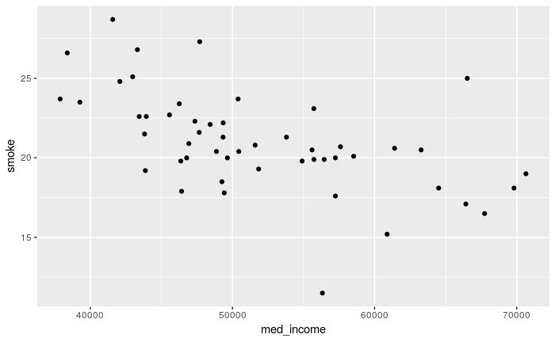

```r
ggplot(state, aes(y = smoke, x = med_income)) +
    geom_point()
```

##### Hypotheses

###### Identify the sample (or samples) and a reasonable population (or populations) of interest.

###### Express the null and alternative hypotheses as contextually meaningful full sentences.

$H_{0}:$ Null hypothesis goes here.

$H_{A}:$ Alternative hypothesis goes here.

###### Express the null and alternative hypotheses in symbols (when possible).

$H_{0}: math$

$H_{A}: math$

##### Model

###### Identify the sampling distribution model.

Please write up your answer here.

###### Check the relevant conditions to ensure that model assumptions are met.

Please write up your answer here. (Some conditions may require R code as well.)

##### Mechanics

###### Compute and report the test statistic.

```r
# Add code here to compute the test statistic.
```

Please write up your answer here.

###### Plot the null distribution.

```r
# Add code here to plot the null distribution.
```

###### Calculate and interpret the P-value.

```r
# Add code here to calculate the P-value.
```

Please write up your answer here.

##### Conclusion

###### State the statistical conclusion.

Please write up your answer here.

###### State (but do not overstate) a contextually meaningful conclusion.

Please write up your answer here.

###### Identify the possibility of either a Type I or Type II error and state what making such an error means in the context of the hypotheses.

Please write up your answer here.

##### Confidence interval

###### Check the relevant conditions to ensure that model assumptions are met.

Please write up your answer here. (Some conditions may require R code as well.)

###### Calculate the confidence interval.

```r
# Add code here to calculate the confidence interval.
```

###### State (but do not overstate) a contextually meaningful interpretation.

Please write up your answer here.

###### If running a two-sided test, explain how the confidence interval reinforces the conclusion of the hypothesis test.

Please write up your answer here.

[^1]: In most places, the Pearson correlation coefficient is denoted by a lowercase r, but the OpenIntro book uses an uppercase R.